# Градиентный спуск - методы работы

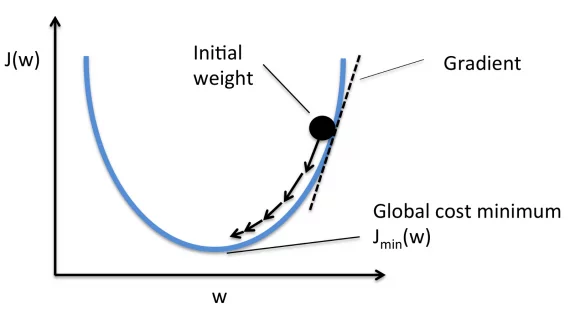

**Градиентный спуск**:

Итеративный метод оптимизации, позволяющий находить минимум(максимум) функции при движении в сторону антиградиента (градиента). *не гарантируетнахождение глобального минимума*

**Градиентом** назовем вектор частных производных показывающий направление наискорейшего роста функции.

$f'(x) = grad f(x) = \nabla f =\dfrac{df(x)}{dx} = (\dfrac{df}{dx_1},\dfrac{df}{dx_2},...,\dfrac{df}{dx_n})$

**Антиградиентом** назовём вектор обратно направленный градиенту и показывающий направление наискорейшего убывания.

Если же у нас имеется функция которая как аргумент принимает функции а на выход выдаёт число, то данную функцию называют **функционалом**.

В области ML данные алгоритмы нашли широкое применение в оптимизациях функционалов ошибки моделей.

Пусть a - модель имеющая некоторые веса $w$ Пусть задана функция потерь (loss function):

$L(y_i, a(x_i))$, где $y_i$ - истинный ответ на i-том объекте $a(x_i)$ - предсказание модели на i-том объекте

Тогда функцией ошибки назовем (например) следующий функционал обобщающий потерю на каждом из объектов : $$Q(a,X) = \dfrac{1}{\ell}\sum^{\ell}_{i=1}L(y_i,a(x_i, w_i))$$

*В качестве $L(y_i,a(x_i))$ - при задаче регресии может выступать SE (squared error), AE (absolute error) и другие*

Решим задачу по поиску минимума функционала ошибки $Q(a(w),X) \rightarrow min_w$ при изменении весов модели.

$$АЛГОРИТМ$$

1. $w^{(0)}$ - начальная случайная инициализация весов
2. Пока не выполнится критерий останова $$w^{k} = w^{k-1} - \eta \nabla Q(w^{(k-1)}) $$ где
   - $w^{k-1}$ - веса модели на предыдущем шаге
   - $\eta$ - learning rate
   - $\nabla Q(w^{(k-1)})$ - градиент функционала ошибки на предыдущем шаге
3. Если выполнился один из критериев останова, считаем что нашли $w_*$ - в котором достигается допустимый минимум функционала ошибки с текущими гиперпараметрами алгоритма.

Возможные критерии останова:

- $||w^k - w^{k-1} || < ε $ - изменение весов незначительно
- $|Q(w^{(k)}) - Q(w^{(k-1)})| < ε$ - изменение функционала ошибки незначительно
- $k > N$ - превышен лимит итераций
- $||\nabla Q(w^{(k)})|| < ε$ - норма градиента незначительна
- $Q(w^k) > Q(w^{(k-1)})$ - функционал ошибки начал увеличиваться

Плюсы:

1. Быстрая сходимость

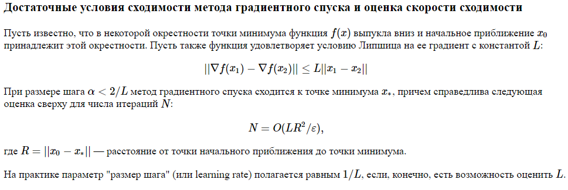

Минусы:

1. Застревание в локальных минимумах - (решение мультистарт с различных точек)
2. Множество условий сходимости
3. Большое время выполнения алгоритма

**Обоснование долгого времени выполнения алгоритма**

Пусть задан функционал ошибки: $$ Q(w) = \dfrac{1}{\ell} \sum^{\ell}_{i=1} L(y_i, a(x_i,w)) $$ Заменим: $$ Q(w) = \dfrac{1}{\ell} \sum^{\ell}_{i=1} q_i(w) $$ Тогда при вычислении градиента, т.к. берем производную от суммы с вынесенной константой можно утверждать что: $$ \nabla Q(w) = \dfrac{1}{\ell} \sum^{\ell}_{i=1} \nabla q_i(w)$$ Таким образом на каждом шаге градиентного спуска необходимо будет вычислить градиент на каждом из объекте обучающей выборке.

Пусть имеем $10^6$ - объектов в обучающей выборке. При этом алгоритм произвел 1000 итераций. Тогда произошло $10^6 \cdot 10^3 = 10^9$ операций.

## Стохастический градиентный спуск

Решим обозначенную ранее проблему, множество итераций на каждом шаге градиентного спуска.

Т.к. градиент функционала ошибки высчитывает по своей сути средний градиент всех объектов, будем производить предположение о среднем градиенте по одному случайному объекту из обучающей выборке.

$Q(w) = \nabla q_i(w)$, где $i$ - случайный индекс объекта из равновероятного распределения индексов.

$$w^{(k)} = w^{(k-1)} - η \nabla q_{ik}(w^{(k-1)})$$

Тогда назовем данный алгоритм **стохастическим градиентным спуском** (stochastic gradient descent) SGD

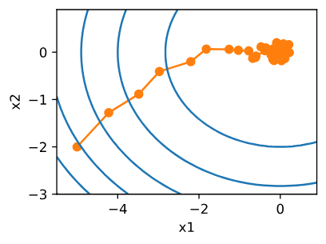

Однако при таком подходе к оценке средней ошибки очень сильно повышается вероятность оссциляций.

Сходимость алгоритма возможна если сделать параметр learning rate - переменным и замедлять движение в конце.

Например $η_k = \dfrac{1}{k} $

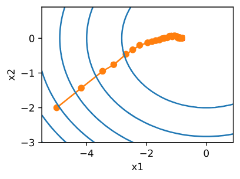

Условия Роббинса-Монро:

$$\begin{cases} \sum_{k=1}^{∞} η_k = ∞ \\ \sum_{k=1}^{∞} η_k^2 < ∞ \end{cases}$$

Если условия Роббинса-Монро выполняются, тогда говорят что алгоритм сходится со скоростью $E(Q(w^{(k)} - Q(w_*))) = O(\dfrac{1}{\sqrt{k}})$

Плюсы:

1. Хорошо подходит для "онлайн обучения" - метод обучения когда размер объектов настолько велик, что не позволяет загружать в память более одного объекта.
2. Высокая скорость работы.

Минусы:

1. Низкая скорость сходимости из-за большого количества колебаний при итерациях.

## Mini Batch Gradient Descent

Предположим, что SGD слишком радикально-экстремален в количестве объектов. Введём число $t$ - количество выбираем объектов для расчёта градиента.

Тогда формула градиента функционала ошибки:

$\nabla Q(w) = \dfrac{1}{t} \sum^{t}_{i=1} \nabla q_i(w)$

$w^{(k)} = w^{(k-1)} - η \nabla Q(w) $

Плюсы:

1. Лучшая траектория (устойчивость)
2. Возможно применять при Deep Learning для параллельности на видеокартах (batch как раз влезает на видеокарту)

Минусы:

1. Увеличивая размер батча в попытках улучшения траектории мы жертвуем временем на каждой из итераций алгоритма. Существенное улучшение сходимости происходит только лишь при $t \rightarrow \ell$ (нужно проверить).

**ps на картинке ниже batch gradient descent** - обычный градиентный спуск

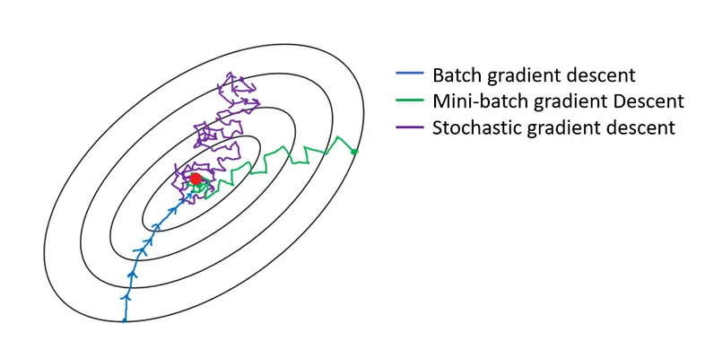

## Stochastic Average Gradient (SAG)

Пусть функционал ошибки $Q(w) = \dfrac{1}{\ell} \sum^{\ell}_{i=1} q_i(w) $

И рассчитаем $z_i^{(0)} = \nabla q_i(w^{(0)})$

Далее на каждой итерации будем выбирать $i_k \in H$ где $H$ - равномерное распределение $\{1,2...\ell\}$

и рассчитывать $z_i^{(k)} = \begin{cases}\nabla q_i(w^{(k-1)}), i = i_k \\ z_i^{(k-1)}, i \neq i_k \end{cases}$

Таким образом получаем:

$$\nabla Q(w^{(k-1)}) = \dfrac{1}{\ell} \sum^{ℓ}_{i=1} z_i^{(k)}$$$$w^{(k)} = w^{(k-1)} - η_k \dfrac{1}{\ell} \sum^{\ell}_{i=1}z_i^{(k)}$$

Данный подход позволяет производить шаг по полному градиенту, при этом производя только расчёт на одном объекте, а для остальных используя старый градиент.

Хорошо подходит когда можно сделать предположение о том, что в целом направление движения не будет сильно изменяться.

Такое предположение допустимо при оптимизации линейных выпуклых функционалах.

Выпуклый функционал $x^2$

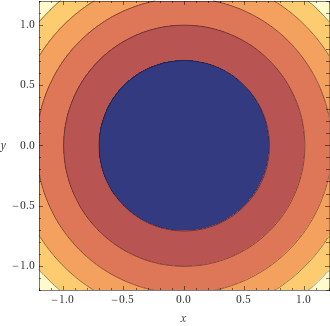

Невыпуклый функционал $$ z = x^2 - 4 y^3 + 17 x y + x^3 7 + y^5 + x^7$$

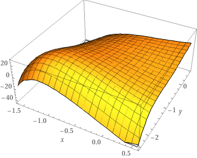

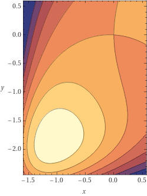

## Метод инерции или SGD with Momentum

Рассмотрим оптимизируемую функцию со следующими линиями уровня:

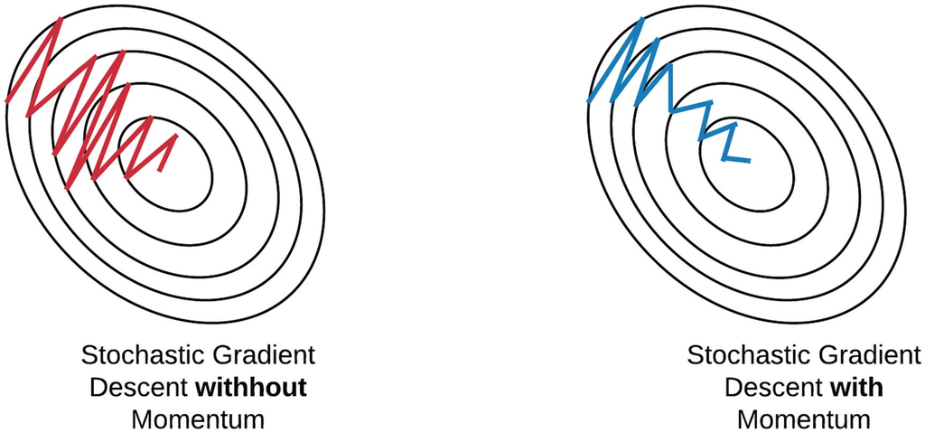

Как мы можем заметить, в данном случае при нахождении минимума функции, возможна ситуация наличия оссциляций по одному из направлений.

Причиной данных оссциляций является направление антиградиента ортогонального направлению линий высоты.

Однако также можно заметить, что движение происходит по направлению ортогональному векторам антиградиента.

Таким образом чтобы уничтожить оссциляции, необходимо просуммировать векторы градиентов на n последующих шагах.

1. $w^{(0)}$ - инициализируем веса начальными значениями;
2. $h_0 = 0$ - инициализируем вектор инерции;
3. $ h_k = \alpha h_{k-1} + η_k \nabla_w Q(w^{(k-1)})$ - рассчитываем вектор энерции;
4. $w^{k} = w^{(k-1)} - h_k$ - рассчитываем вектор весов;

Плюсы:

1. Уменьшение оссциляций с увеличением количества итераций

## Adagrad

Допустим что наш тренировочный датасет содержит множество признаков с сильной разряженностью (матрица признаков $X$ сильно разряжена).

Тогда логичным будет взвешивать $η$ для каждого признака. Допустим один из них встречается очень редко и мы должны сделать сильный шаг, а другой признак встречается часто и логично будет сделать шаг меньше.

$G_{0j} = 0$, где первый индекс - итерация, j - номер признака

$G_{kj} = G_{k-1,j} + (\nabla Q(w^{k-1}))_j^2$ - подсчитываем насколько сильно мы уже обновляли этот вес

$w_j^{(k)} = w_j^{(k-1)} - \dfrac{η_k}{\sqrt{G_{kj} + \epsilon}} \cdot (\nabla_w Q(w^{(k-1)}))_j$ - в знаменателе происходит нормировка на то насколько сильно уже обновляли в этом весе

Минусы:

1. $G_{k i} $ - не уменьшается а только растет

Решение - RMSPROP

## RMSPROP

Произведем модификацию Adagrad для возможности уменьшения весов:

$G_{kj} = \alpha G_{k-1,j} + (1-\alpha) (\nabla Q (w^{(k-1)}))^2_j$

Выбирая коэффициенты $\alpha , (1-\alpha) $ - можем добиться уменьшения весов.

## Линейная регрессия

Пусть имеется объект представленный в виде вектора $ x = (x_1,x_2,x_3...x_d)$, тогда линейной моделью назовем: $$a(x) = w_0 + \sum^d_{i=1}w_ix_i$$, где $w_i$ - веса $x_i$ - признак $w_0$ - bias, $w_i \in R$

Пусть в каждом из наших объектов будет единичный признак. Тогда можно записать модель линейной регресии как:

$$ a(x) = w_0 + <w,x> $$

Свойства:

1. Признаки влияют на прогноз независимо
2. Признаки влияют линейно
3. Необходимо подготавливать данные для линейной регресии
4. Возможно включение нелинейных функционалов как признаков

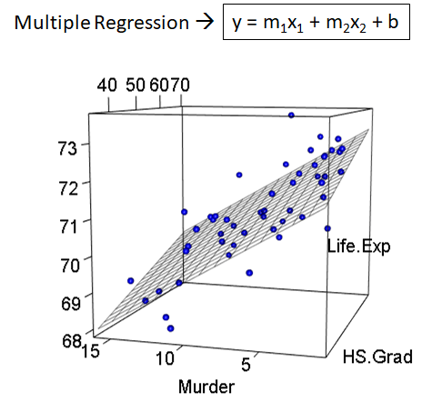

## Ridge Regression

При обучении моделей возможно получения ситуации переобучения (когда наша модель находит оптимальное решение на тренировочном множестве, однако данное решение не является обобщенным на всех данных включая тестовое множество)

Известный экспериментальный факт: в линейных моделях при переобучении веса принимают большие значения. (теоритической обоснованности не найдено но интуитивно т.к. подгоняем решение под множество точек из обучающей выборки, то функционал ошибки будет минимизироваться а веса соответственно расти, что приведет к резким изгибам и подгонам под точки)

Почему это плохо? Пусть имеем модель $$a(x) = 10^8 \cdot area + 10^9 \cdot district + 10^{10} \cdot floor$$ тогда если у нас площадь изменяется на 0.001 (допустим метра) то прогноз изменится на $10^5$.

Решение - запрещаем модели иметь большие веса (однако если признаки не по масштабу target тогда запрещать не надо)

$$Q(w) + \alpha R(w) \rightarrow min$$

- общая форма регуляризатора

В качестве $R(w)$ могут выступать:

$R(w) = ||w||^2_2 = \sum^d_{i=1} w_i^2 $ - l_2 регуляризация

$R(w) = ||w|| = \sum^d_{i=1} |w_i| $ - l_1 регуляризация

$\alpha$ - коэффициент регуляризации

- $\alpha = 0$ - нет регуляризации
- $\alpha >> 0 → w=0 $

Тонкость: $\alpha$ нельзя подобрать на обучающей выборке, необходимо подбирать на valid

Ridge Regression - линейная регрессия с MSE и L2 регуляризацией

$$\dfrac{1}{\ell} \sum^{\ell}_{i=1} (<w,x_i> - y_i)^2 + \alpha ||w||^2_2 → min$$

## Weight decay

Weight Decay - метод также является методом регуляризации, но добавляет штраф для шага (в зависимости от веса признака)

$ w_{k} = (1- \dfrac{\eta λ}{|batch|})w_t - \eta \cdot g_t$

$λ$ - коэффициент уменьшения (небольшое положительное число)

## Lasso Regression

Lasso Regression - линейная регрессия с MSE и L1 регуляризацией - т.к. зануляет часть весов называется лассо

$$\dfrac{1}{\ell} \sum^{\ell}_{i=1} (<w,x_i> - y_i)^2 + \alpha ||w|| → min$$

Замечание:

При наличии признаков разных масштабов больший вес будет у признака с меньшим масштабом. Если применять регуляризации на признаки с разными масштабами, веса будут уравновешиваться и вести регуляризация будет вести себя неадекватно.

Решение - применение масштабирования

Также регуляризация ускоряет градиент спуск т.к. упрощает рельеф функционала

Масштабирование - преобразовывает линии уровня функционала в более округлые, что также ускоряет градиентый спуск

Если необходимо интерпретировать веса, необходимо сделать преобразование обратное масштабированию.

## Logistic Regression

Для решения данной задачи пусть наша модель предсказывает значение в диапазоне $(-\infty, +\infty)$ после чего преобразуем выход модели в вероятности через

$\langle w , y \rangle = log(\dfrac{p}{1-p})$ - логарифм отношения положительного события к отрицательному

$ e^{\langle w , y \rangle} = \dfrac{p}{1-p}$

$p = \dfrac{1}{1 + e^{-{\langle w , y \rangle}}}$

$σ(z) = \dfrac{1}{1+e^{-z}}$

$ p = σ({\langle w , y \rangle})$